# Visual Studio Code and Anaconda Installation Tutorial

- [Visual Studio Code (aka. VS code)](https://code.visualstudio.com/) is a code editor redefined and optimized for building and debugging modern web and cloud applications.
- [Anaconda](https://www.anaconda.com/) is a useful tool for python environment management

## 1. [Anaconda](https://www.anaconda.com/) installation

You can either install [Anaconda](https://www.anaconda.com/products/individual#windows) or [Miniconda](https://docs.conda.io/en/latest/miniconda.html), however for this tutorial, I'll show you how to install miniconda

### 1.1 Download miniconda

Download miniconda via this [site](https://docs.conda.io/en/latest/miniconda.html) or use [this link(exe)](https://repo.anaconda.com/miniconda/Miniconda3-latest-Windows-x86_64.exe) to get 64-bit the exe

### 1.2 Keep pressing **next** or **I agree** until this page show up, make sure to check `register Miniconda3 as my default Python 3.8`

[figure not shown]

### 1.3 Wait for the installation to complete

### 1.4 Press start and type `Anaconda Powershell prompt`

[figure not shown]

### 1.5 create this subject environment using the following command

```
conda create -n comprog_enc python=3.8 -y
```

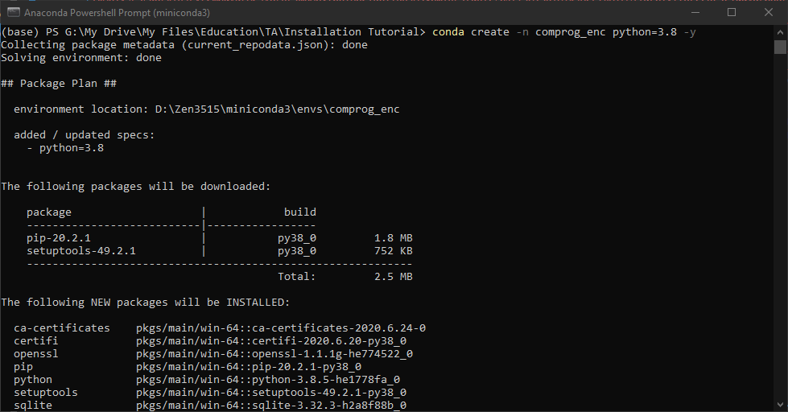

### 1.6 activate the environment

```
conda activate comprog_enc
```

[figure not shown]

### 1.7 install [pygame library](https://pypi.org/project/pygame/)

```
pip install pygame
```

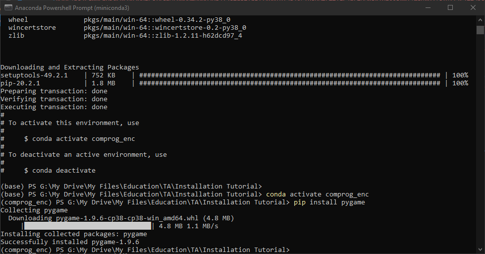

### Anaconda installation is completed

## 2. [Visual Studio Code (aka. VS code)](https://code.visualstudio.com/) Installation

### 2.1. Download installer from the web site or click the links below

- [Windows](https://aka.ms/win32-x64-user-stable)
- [Linux](https://go.microsoft.com/fwlink/?LinkID=760868)
- [Mac](https://go.microsoft.com/fwlink/?LinkID=620882)

### 2.2. open installer

### 2.3. Accep the agrement and next

[figure not shown]

### 2.4 Next while keeping every other option check

[figure not shown]

### 2.5 repeat next and wait for installation to finish then open VS code

### 2.6 select extension page then type `python` then press install (mine is already install)

[figure not shown]

### 2.7 Also install Anaconda extension pack

[figure not shown]

### 2.8 Click `File>New File`

[figure not shown]

### 2.9 save the file as python `hello.py`

[figure not shown]

[figure not shown]

### 2.10 type in

```
print("Hello Comprog")
```

[figure not shown]

### 2.11 Save `File>Save` or `Ctrl + S`

### 2.12 change environment to `comprog_enc`

[figure not shown]

### 2.13 Running in terminal by `right click > Run Python File in Terminal`

[figure not shown]

### 2.14 make sure you see `Hello ComProg` show up in the terminal

[figure not shown]

### 2.15 Test library `Pygame`

### 2.16 First download and extract [this file](https://bit.ly/2KF64vf)

### 2.17 Open that folder up in VS code `File > Open Folder`

### 2.18 Open setting using `Ctrl + Shift + P` type `Open Settings (json)`

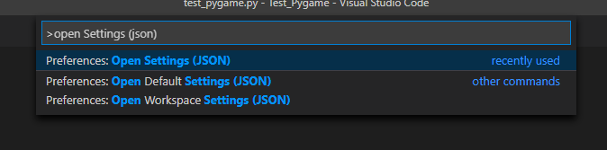

### 2.19 add the following to the setting then save

```
{
    "[python]": {
        "editor.defaultFormatter": "ms-python.python",
        "editor.formatOnSave": true
    },
    "python.formatting.provider": "autopep8",
    "python.formatting.autopep8Args": [
        "--max-line-length=150",
    ],
    "python.linting.pylintEnabled": true,
    "python.linting.pylintArgs": ["--generate-members"]
}
```

### 2.20 back to the file `test_pygame.py` `right click > Run Python FIle in Terminal` and you should get this window show up

[figure not shown]